# Rolling Correlation of SPX Constituents

Given a database of stock prices, how might we calculate rolling correlations between constituents of the S&P 500 index?

For problems like this, the `tidyverse` really shines. There are a number of ways to solve this problem … read on for our solution, and let us know if you’d approach it differently.

First, we load some packages and some data that we extracted earlier. `spxprices.RData` contains a dataframe, `prices_df`, of S&P500 constituents and their daily prices. It also contains a boolean flag `inSPX` which defines whether the stock was in the index that month. (we prepared this upstream using BigQuery).

```r
library(tidyverse)
library(glue)
library(here)
load(here::here("data", "spxprices.RData"))
prices_df %>%
  head()
```

| ticker | date | open | high | low | close | volume | dividends | closeunadj | inSPX |
| --- | --- | --- | --- | --- | --- | --- | --- | --- | --- |
| A | 2019-11-29 | 80.96 | 81.240 | 80.47 | 80.77 | 835780 | 0 | 80.77 | TRUE |
| AAL | 2019-11-29 | 28.92 | 29.265 | 28.66 | 28.74 | 2970843 | 0 | 28.74 | TRUE |
| AAP | 2019-11-29 | 158.46 | 159.010 | 156.68 | 157.08 | 487131 | 0 | 157.08 | TRUE |
| AAPL | 2019-11-29 | 266.60 | 268.000 | 265.90 | 267.25 | 11654363 | 0 | 267.25 | TRUE |
| ABBV | 2019-11-29 | 88.00 | 88.090 | 87.22 | 87.73 | 3042787 | 0 | 87.73 | TRUE |
| ABC | 2019-11-29 | 87.96 | 88.750 | 87.78 | 87.91 | 355792 | 0 | 87.91 | TRUE |

We’d like to be able to calculate rolling average pairwise correlations between all the stocks (or subsets of them) in as tidy a way possible.

That is, we would calculate the rolling pairwise correlation between all the stock combinations in the index and then take the mean of all those.

Our general aproach was to:

- calculating returns for each ticker
- create a long dataframe of all the combinations that were in the index for each day by doing a full join of the data on itself
- remove instances where we had the same stock twice (corresponding to the diagonal of the correlation matrix)
- remove instances where we have the same stock, but in different columns, eg we only want one of APPL-GOOG and GOOG-APPL (this is equivalent to removing the upper or lower triangle of the correlation matrix)
- use `slider::slide2_dbl` to do the rolling correlation calculation
- group by date and take the mean

We run into trouble trying to do the full join on all the data - the resulting object is about 15GB in size.

[figure not shown]

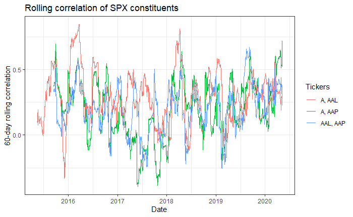

```r
pairwise_corrs %>%
  na.omit() %>%
  filter(tickers %in% c("A, AAL", "A, AAP", "AAL, AAP")) %>%
  ggplot(aes(x = date, y = rollingcor, colour = tickers)) +
    geom_line() +
    labs(
      x = "Date",
      y = glue("{period}-day rolling correlation"),
      title = "Rolling correlation of SPX constituents",
      colour = "Tickers"
    ) +
    theme_bw()
```

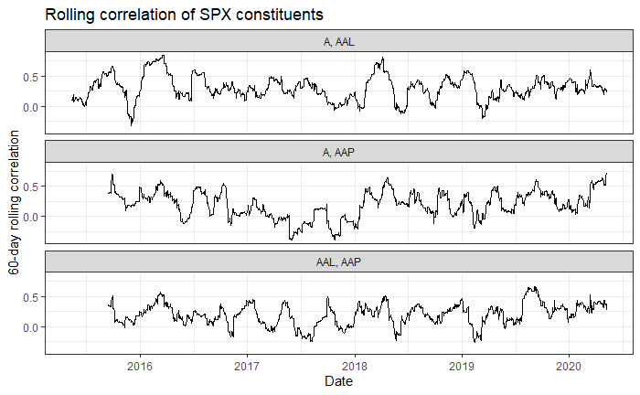

```r
p <- pairwise_corrs %>%
  na.omit() %>%
  filter(tickers %in% c("A, AAL", "A, AAP", "AAL, AAP")) %>%
  ggplot(aes(x = date, y = rollingcor)) +
    geom_line() +
    facet_wrap(~tickers, ncol = 1) +
    labs(
      x = "Date",
      y = glue("{period}-day rolling correlation"),
      title = "Rolling correlation of SPX constituents"
    ) +
    facet_wrap(~tickers, ncol = 1) +
    theme_bw()

p
```

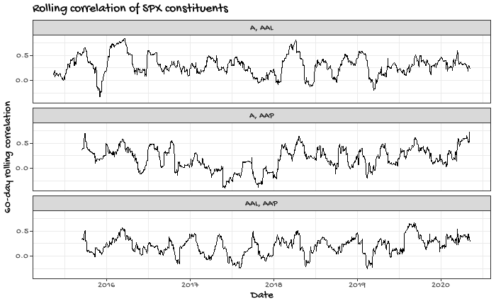

```r
library(showtext)
font_add_google("Gochi Hand", "gochi")

showtext_auto()
p + theme_bw(base_family =  "gochi")
```